# Final Project Milestone

CMSC471: Introduction to Information Visualization (Spring 2025)

The goal of this lab is to help you test-drive your prototype, share progress with peers, and gather actionable feedback to improve your final visualization.

By now, your GitHub repository should contain an initial prototype of your project. The prototype does **not** need to be polished or fully complete—but it should demonstrate clear progress, including working (even if rough) versions of your visualizations and interactions.

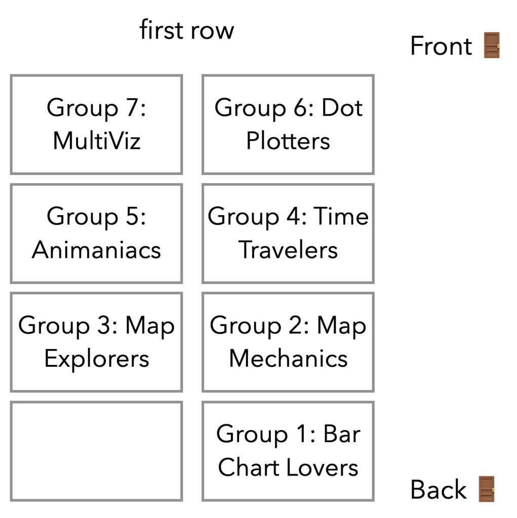

# Session Setup

Please move to your assigned area and settle in with your team. A few notes:

- You’ll work in groups of 2–4 teams, rotating to review each other’s work.
- If your code is buggy or unstable, we **recommend recording a short demo video** in advance to avoid technical issues.
- Course staff will circulate to check progress and join your discussions.

Open the [peer feedback spreadsheet](https://docs.google.com/spreadsheets/d/1MeofEvKzr20O-gtjUYWz2pAz3aRPJu_NLUnkfqHqBpQ/edit?gid=1358119969#gid=1358119969) to record your observations and feedback. While this milestone is mainly graded based on team participation, staff may spot-check the quality of your feedback.

# Talk-through Instructions

Each student should be prepared to **give a short walkthrough** (5–8 minutes total) of your team’s current prototype. This will help you practice for the final demo and receive structured critique.

Please include the following points:

1. **(1–2 min) Introduction.** Briefly introduce your dataset and project goals. What is your visualization trying to help the user understand or do, and why does it matter?
2. **(2–3 min) Demo.** Show the current version of your visualization. Highlight the main view(s), interaction(s), or animations—even if still in-progress.
3. **(1–2 min) Design rationale.** What key design choices have you made so far? Did you perform any data exploration that informed your direction? What encodings, layouts, or techniques did you try, keep, or discard?
4. **(1–2 min) Peer questions.** Discuss 1–2 specific areas where you’d like feedback. These could be questions about usability, engagement, interactivity, or alternative design directions.

# Peer Feedback Prompts

After each presentation, spend ~5 minutes interacting with the prototype and writing feedback. Use the following prompts to guide your critique:

### Visual Encodings

- Do the visual encodings clearly reveal key patterns, trends, or comparisons?
- Is anything important hard to see or overly reliant on interaction?
- Would the intended audience likely understand this display?

### Interactivity & Animation

- Are interaction techniques (hover, click, filter, scroll, etc.) useful and engaging?
- Do they aid exploration and learning—or feel confusing or unnecessary?
- Is the performance smooth and usable?

### Design Quality

- Are layout, spacing, typography, and organization visually clear?
- Is it easy to know where to start and how to explore?
- Does the overall prototype feel cohesive and aligned with project goals?